# Reproducible Research: Peer Assessment 1

Dandeliontree

12 February 2016

https://github.com/Liyenz/RepData_PeerAssessment1/blob/master/PA1_template.md

https://github.com/LH-datascience/RepData_PeerAssessment1/blob/master/PA1_template.md

https://github.com/vbondarevsky/RepData_PeerAssessment1/blob/master/PA1_template.md

## Loading and preprocessing the data

Set-up the environment  
Load the required libraries & set WD

```r
    library("lattice")
    library(dplyr)
      library(timeDate)
    library(data.table)
      working.dir <- "E://Coursera//Data_Scientist//reproducable_research//peer_assessment//pa_one"
      setwd(working.dir)
```

Load the data Assumption is that the data exists in the ./data directory in a raw (non archived form)

```r
      activity.raw.data<-as.data.table(read.csv(".//data//activity.csv",header=TRUE))
```

## What is mean total number of steps taken per day?

Analysis excluding missing values.

[figure not shown]

```r
    #construct DT witout misisng values.
      activity.raw.no.na<-filter(activity.raw.data,!is.na(steps))
    #Group by day.
      activity.by.day.no.na <- group_by(activity.raw.no.na,date)
      summary.steps.day<-summarize(activity.by.day.no.na,total_steps_per_day=sum(steps),median_steps_per_day=median(steps),average_steps_per_day=mean(steps))


    #Histogram
        hist(summary.steps.day$total_steps_per_day, breaks = 30,col = "red1",xlab="Average Number of Steps per day",main="Average number of streps per day- excludes missing values")
```

```r
print(paste0("Mean Steps per day: ",mean(summary.steps.day$average_steps_per_day)))
```

[output not shown]

```r
print(paste0("Median Steps per day: ",median(summary.steps.day$median_steps_per_day)))
```

[output not shown]

## What is the average daily activity pattern?

Question 2.1: Make a time series plot (i.e. type = “l”) of the 5-minute interval (x-axis) and the average number of steps taken, averaged across all days (y-axis)

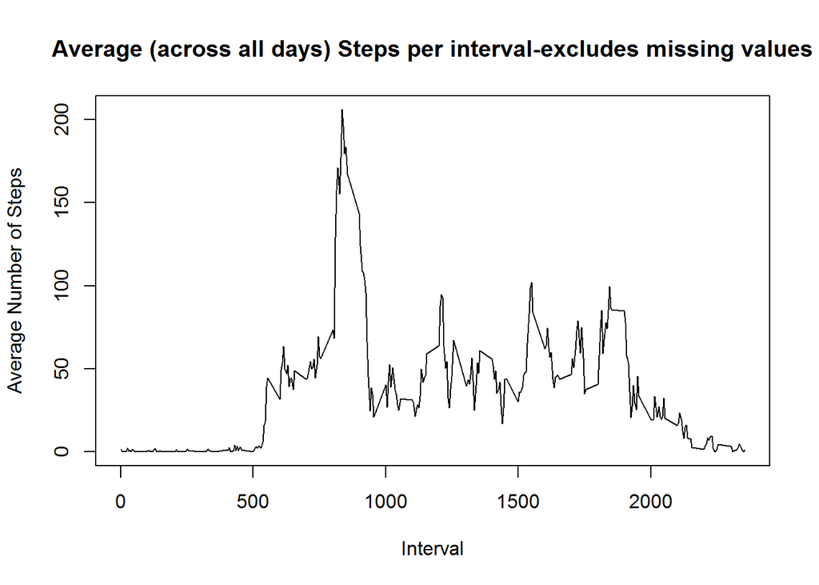

```r
        activity.by.interval.no.na <- group_by(activity.raw.no.na,interval)
        summary.steps.period<-summarize(activity.by.interval.no.na,average_steps_per_interval=mean(steps))

    #Plot Time Series
        plot(summary.steps.period$interval,summary.steps.period$average_steps_per_interval, type = "l",ylab="Average Number of Steps",xlab="Interval", main="Average (across all days) Steps per interval-excludes missing values" )
```

Question 2.2: Which 5-minute interval, on average across all the days in the dataset, contains the maximum number of steps?

```r
    #Periods with Max Steps
        steps.period.desc <- arrange(summary.steps.period, desc(average_steps_per_interval))

    #print top interval
        print(paste0("The following five min interval contains the max number of steps: ",head(steps.period.desc,1)$interval))
```

```
## [1] "The following five min interval contains the max number of steps: 835"
```

## Inputing missing values

Question 3.1: Calculate and report the total number of missing values in the dataset (i.e. the total number of rows with NAs)

```r
        activity.raw.is.na<-filter(activity.raw.data,is.na(steps))
        print(paste0("The total number of misisng valuses is: ",count(activity.raw.is.na)$n))
```

```
## [1] "The total number of misisng valuses is: 2304"
```

Question 3.2: Devise a strategy for filling in all of the missing values in the dataset. The strategy does not need to be sophisticated. For example, you could use the mean/median for that day, or the mean for that 5-minute interval, etc..

```r
#Equivellent to an inner Join.
        activity.raw.replaced.na<-merge(activity.raw.is.na,summary.steps.period,by = "interval")
#Round the values
        activity.raw.replaced.na<-mutate(activity.raw.replaced.na,steps=round(average_steps_per_interval))
```

Question 3.3: Create a new dataset that is equal to the original dataset but with the missing data filled in.

```r
#Project the relevant attributes
        activity.raw.replaced.na<-select(activity.raw.replaced.na,interval,date,steps)
        activity.raw.final.no.na <- rbind(activity.raw.replaced.na,activity.raw.no.na)
```

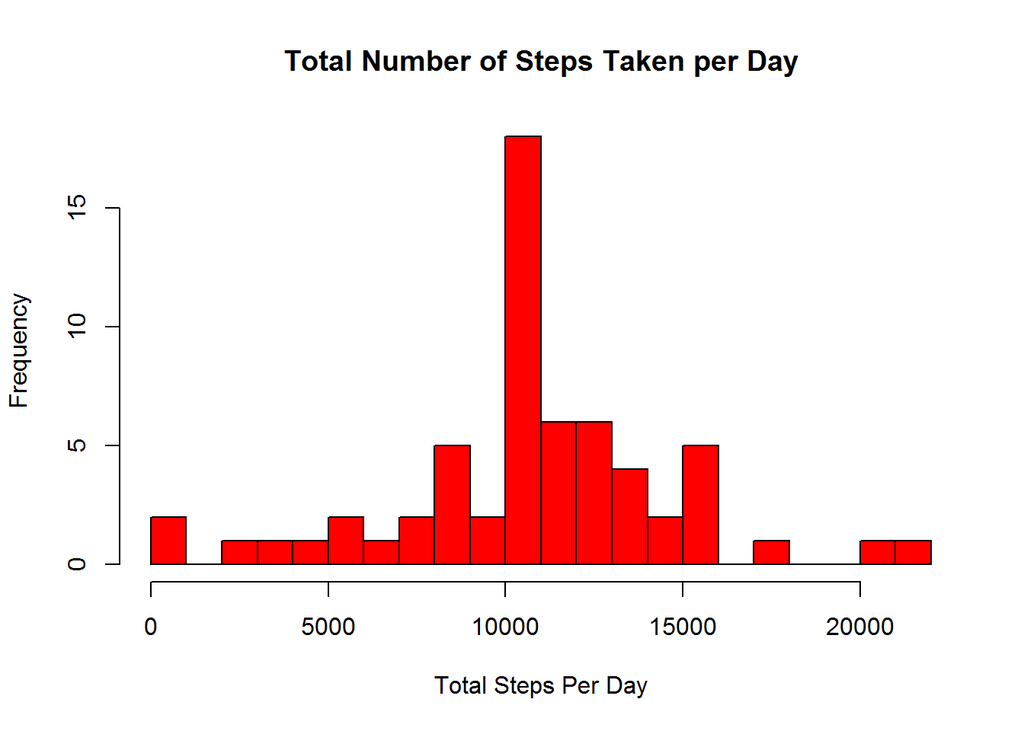

```r
#Group by day.
        activity.by.day.final.no.na <- group_by(activity.raw.final.no.na,date)
        summary.steps.day.final.no.na<-summarize(activity.by.day.final.no.na,total_steps_per_day=sum(steps),median_steps_per_day=median(steps),average_steps_per_day=mean(steps))
    #Histogram
        hist(summary.steps.day.final.no.na$total_steps_per_day, breaks = 30,col = "red1",xlab="Total Steps Per Day",main="Total Number of Steps Taken per Day")
```

## Are there differences in activity patterns between weekdays and weekends?

Question 3.1: Create a new factor variable in the dataset with two levels - “weekday” and “weekend” indicating whether a given date is a weekday or weekend day.

```r
    ###factor.weekend.raw.no.na<- mutate(activity.raw.final.no.na, is_weekend=isWeekend(as.Date(date)))
        factor.weekend.raw.no.na<- mutate(activity.raw.final.no.na, date=ifelse(isWeekend(as.Date(date)), 'Weekend', 'Weekday'))
      factor.weekend.raw.no.na$date<-factor(factor.weekend.raw.no.na$date)
      factor.weekend.raw.no.na<-mutate(factor.weekend.raw.no.na,date=(date))
```

Question 3.2: Make a panel plot containing a time series plot (i.e. type = “l”) of the 5-minute interval (x-axis) and the average number of steps taken, averaged across all weekday days or weekend days (y-axis). See the README file in the GitHub repository to see an example of what this plot should look like using simulated data.

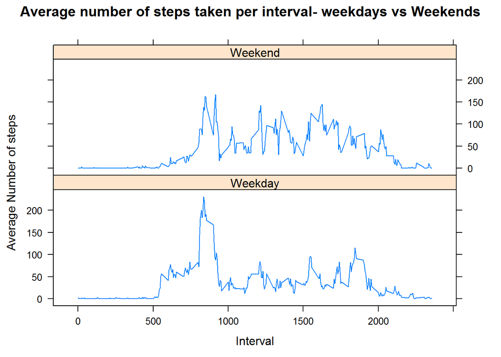

```r
  tst <- group_by(factor.weekend.raw.no.na,date,interval)
    weekend.summary.steps.interval<-summarize(tst,average_steps_per_day=mean(steps))

    xyplot(average_steps_per_day ~ interval| levels(weekend.summary.steps.interval$date),
           data = weekend.summary.steps.interval,
           type = "l",
           xlab = "Interval",
           ylab = "Average Number of steps",
             main = "Average number of steps taken per interval- weekdays vs Weekends",
           layout=c(1,2))
```